# Special Course with MedTek Huset: Value of PET/CT Image Biomarkers in Head and Neck Cancer

Student ID: qtr576

2024-01-19

*This assignment text is broadly based on the references listed in (T. Shceike, F. Eriksson, 2023)*

### Overview

The Department of Nuclear Medicine and PET at Rigshospitalet annually conducts approximately 150 scans for patients with Head and Neck Cancer (HNC) to facilitate the planning of radiotherapy treatment. The treatment of HNC involves a complex clinical process, including manual delineation of tumor volumes on PET/CT images by physicians. The resulting volume is crucial for assessing the area to be irradiated and determining regions that may require an increased radiation dose compared to normal.

Through the delineation of tumors, a variety of physiological image biomarkers can be calculated, some of which are presumed to possess independent predictive value for locoregional control and survival. This report will explore the biomarker, metabolic tumor volume measured by deep learning, through survival analysis, including the use of the Kaplan-Meier estimator and Cox proportional hazard model.

The data is first prepared

```r
library(dplyr)
library(tidyr)
library(knitr)
library(kableExtra)
library(survival)
library(survminer)
library(ggfortify)
library(mets)
library(prodlim)
library(riskRegression)
```

```r
# Setting the working directory
setwd("H:\\Special kursus")

# Reading the CSV file
PET <- read.csv("pet_ct_biomarkers_surv til R.csv", na.strings = c("", "NA"))
```

The dataset consists of 1198 rows and 24 columns of patient data.

1. `x`: # patient
2. `dataset_num`: Number of datasets drawn
3. `institution`: Hospital where the scan was performed
4. `sex`: Gender
5. `scan_date_datetime`: Date of scan
6. `age_at_scan`: Age of the patient at the time of the scan
7. `dose_MBq`: Dose of contrast agent (18F-FDG) injected measured in MBq
8. `inj_to_scan_time`: Time between injection and scanning time
9. `weight`: Patient’s weight at the time of the scan
10. `anon_id`: Patient ID
11. `mors_date`: Date of death (if the patient has died, otherwise it is date the data is drawn, 07-07-2023)
12. `patient_region`: Region to which the patient belongs
13. `mtv_dl`: Metabolic tumor volume measured by deep learning
14. `mtv_ph`: Metabolic tumor volume measured by a physician
15. `n_objects_dl`: Number of abnormalities found on the scan by deep learning
16. `n_objects_ph`: Number of abnormalities found on the scan by a physician
17. `suv_max_dl`: Maximum standardized uptake value measured by deep learning
18. `suv_max_ph`: Maximum standardized uptake value measured by a physician
19. `suv_mean_dl`: Mean standardized uptake value measured by deep learning
20. `suv_mean_ph`: Mean standardized uptake value measured by a physician
21. `tlg_dl`: Total lesion glycolysis (SUV_mean x mtv) measured by deep learning
22. `tlg_ph`: Total lesion glycolysis (SUV_mean x mtv) measured by a physician
23. `event`: Determines if the patient is dead (true) or alive (false)
24. `time_to_morse`: Days from scan date to date of death

```r
PET <- subset(PET, dataset_num == 1)

PET <- PET %>%
  select(-c(dataset_num, institution, scan_date_datetime, dose_MBq, mors_date, patient_region, mtv_ph, n_objects_dl, n_objects_ph, suv_max_dl, suv_max_ph, suv_mean_dl, suv_mean_ph, tlg_dl, tlg_ph))
```

Table 1 displays baseline data from the PET dataset

```r
# Replacing non-numeric values in mtv_dl with zero
PET$mtv_dl <- ifelse(grepl("^\\d+\\.?\\d*$", PET$mtv_dl), as.numeric(PET$mtv_dl), 0)
```

```
Advarsel: NAs introduced by coercion
```

```r
Table_1 <- PET %>%
  summarise(
    "Periode of scan dates" = "30-06-2010 to 31-05-2019",
    "Sample size" = n(),
    "Male (sex)" = format(sum(sex == "m", na.rm = TRUE), digits = 3),
    "Female (sex)" = format(sum(sex == "f", na.rm = TRUE), digits = 3),
    "Age (mean (sd))" = paste0(format(mean(age_at_scan, na.rm = TRUE), digits = 3), "  (", format(sd(age_at_scan, na.rm = TRUE), digits = 3), ")"),
    "Male age (mean (sd))" = paste0(format(mean(age_at_scan[sex == "m"], na.rm = TRUE), digits = 3), "  (", format(sd(age_at_scan[sex == "m"], na.rm = TRUE), digits = 3), ")"),
    "Female age (mean (sd))" = paste0(format(mean(age_at_scan[sex == "f"], na.rm = TRUE), digits = 3), "  (", format(sd(age_at_scan[sex == "f"], na.rm = TRUE), digits = 3), ")"),
    "Weight (mean (sd)) [kg]" = paste0(format(mean(weight, na.rm = TRUE), digits = 3), "  (", format(sd(weight, na.rm = TRUE), digits = 3), ")"),
    "Male weight (mean (sd)) [kg]" = paste0(format(mean(weight[sex == "m"], na.rm = TRUE), digits = 3), "  (", format(sd(weight[sex == "m"], na.rm = TRUE), digits = 3), ")"),
    "Female weight (mean (sd)) [kg]" = paste0(format(mean(weight[sex == "f"], na.rm = TRUE), digits = 4), "  (", format(sd(weight[sex == "m"], na.rm = TRUE), digits = 3), ")"),
    "Patients registered alive" = paste0(format(mean(event == "True", na.rm = TRUE) * 100, digits = 4), "%"),
    "Patients registered dead" = paste0(format(mean(event == "False", na.rm = TRUE) * 100, digits = 4), "%"),
    "Metabolic tumor volume deep learning (mtv_dl) (mean (sd))" = paste0(format(mean(PET$mtv_dl, na.rm = TRUE), digits = 4), " (", format(sd(PET$mtv_dl, na.rm = TRUE), digits = 4), ")"),
    "Time to death (mean (sd)) [days]" = paste0(format(mean(time_to_morse, na.rm = TRUE), digits = 4), " (", format(sd(time_to_morse, na.rm = TRUE), digits = 4), ")")
  ) %>%
  gather(key = "Variables", value = "Population")

# Creating two extra columns for the patients dead or alive
PET_dead <- subset(PET, event == "True")
PET_alive <-subset(PET, event == "False")

Table_1 <- Table_1 %>%
  mutate(Alive = c("28-12-2011 to 28-05-2019",
               sum(PET$event == "False", na.rm = TRUE),
               format(sum(PET_alive$sex == "m", na.rm = TRUE), digits = 3),
               format(sum(PET_alive$sex == "f", na.rm = TRUE), digits = 3),
               paste0(format(mean(PET_alive$age_at_scan, na.rm = TRUE), digits = 3), " (", format(sd(PET_alive$age_at_scan, na.rm = TRUE), digits = 3), ")"),                paste0(format(mean(PET_alive$age_at_scan[PET_alive$sex == "m"], na.rm = TRUE), digits = 3), "  (", format(sd(PET_alive$age_at_scan[PET_alive$sex == "m"], na.rm = TRUE), digits = 3), ")"),
               paste0(format(mean(PET_alive$age_at_scan[PET_alive$sex == "f"], na.rm = TRUE), digits = 3), "  (", format(sd(PET_alive$age_at_scan[PET_alive$sex == "f"], na.rm = TRUE), digits = 3), ")"),
               paste0(format(mean(PET_alive$weight, na.rm = TRUE), digits = 3), "  (", format(sd(PET_alive$weight, na.rm = TRUE), digits = 3), ")"),
               paste0(format(mean(PET_alive$weight[PET_alive$sex == "m"], na.rm = TRUE), digits = 3), "  (", format(sd(PET_alive$weight[PET_alive$sex == "m"], na.rm = TRUE), digits = 3), ")"),
               paste0(format(mean(PET_alive$weight[PET_alive$sex == "f"], na.rm = TRUE), digits = 3), "  (", format(sd(PET_alive$weight[PET_alive$sex == "f"], na.rm = TRUE), digits = 3), ")"),
               paste0(format(mean(PET_alive$event == "True", na.rm = TRUE) * 100, digits = 3), "%"),
               paste0(format(mean(PET_alive$event == "False", na.rm = TRUE) * 100, digits = 3), "%"),
               paste0(format(mean(PET_alive$mtv_dl, na.rm = TRUE), digits = 3), " (", format(sd(PET_alive$mtv_dl, na.rm = TRUE), digits = 3), ")"),
               paste0(format(mean(PET_alive$time_to_morse, na.rm = TRUE), digits = 3), " (", format(sd(PET_alive$time_to_morse, na.rm = TRUE), digits = 3), ")")
               ),

         Dead = c("30-06-2021 to 31-05-2019",
                sum(PET$event == "True", na.rm = TRUE),
                format(sum(PET_dead$sex == "m", na.rm = TRUE), digits = 3),
                format(sum(PET_dead$sex == "f", na.rm = TRUE), digits = 3),
                paste0(format(mean(PET_dead$age_at_scan, na.rm = TRUE), digits = 3), " (", format(sd(PET_dead$age_at_scan, na.rm = TRUE), digits = 3),")"),                   paste0(format(mean(PET_dead$age_at_scan[PET_dead$sex == "m"], na.rm = TRUE), digits = 3), "  (", format(sd(PET_dead$age_at_scan[PET_dead$sex == "m"], na.rm = TRUE), digits = 3), ")"),
                paste0(format(mean(PET_dead$age_at_scan[PET_dead$sex == "f"], na.rm = TRUE), digits = 3), "  (", format(sd(PET_dead$age_at_scan[PET_dead$sex == "f"], na.rm = TRUE), digits = 3), ")"),
                paste0(format(mean(PET_dead$weight, na.rm = TRUE), digits = 3), "  (", format(sd(PET_dead$weight, na.rm = TRUE), digits = 3), ")"),
                paste0(format(mean(PET_dead$weight[PET_dead$sex == "m"], na.rm = TRUE), digits = 3), "  (", format(sd(PET_dead$weight[PET_dead$sex == "m"], na.rm = TRUE), digits = 3), ")"),
                paste0(format(mean(PET_dead$weight[PET_dead$sex == "f"], na.rm = TRUE), digits = 3), "  (", format(sd(PET_dead$weight[PET_dead$sex == "f"], na.rm = TRUE), digits = 3), ")"),
                paste0(format(mean(PET_dead$event == "True", na.rm = TRUE) * 100, digits = 3), "%"),
                paste0(format(mean(PET_dead$event == "False", na.rm = TRUE) * 100, digits = 3), "%"),
                paste0(format(mean(PET_dead$mtv_dl, na.rm = TRUE), digits = 3), " (", format(sd(PET_dead$mtv_dl, na.rm = TRUE), digits = 3), ")"),
                paste0(format(mean(PET_dead$time_to_morse, na.rm = TRUE), digits = 3), " (", format(sd(PET_dead$time_to_morse, na.rm = TRUE), digits = 3), ")")
                ))


# Adding a title to the table using the caption argument
Table_1 %>%
  kable("html") %>%
  kable_styling(full_width = FALSE, position = "center", bootstrap_options = c("striped", "hover", "condensed"), html_font = "helvetica") %>%
  gsub('<thead>', '<thead><tr><th colspan="Table 1 and Baseline Data">Table 1 and Baseline Data</th></tr></thead>', .)
```

[output not shown]

```r
NA
```

### Analysis and Discussion

The non-parametric Kaplan-Meier (KM) method is used to estimate survival probabilities over time in typically clinical studies, where the interest is the time to an event. The KM estimator is employed to address censoring (Professor Marin, 2020). In this study, when talking about censoring, it is implied that it refers to right censoring, which is employed when a patient is still alive after the study period or exits the study independently of the event during the follow-up duration. This method allows the creation of an estimated survival function, offering insights into the probability of survival over time, even in the presence of censored observations. Utilizing censoring as a tool in survival analysis facilitates the analysis of data that, in reality, lies beyond the study’s knowledge, as participants have not experienced the event or exited before they have.

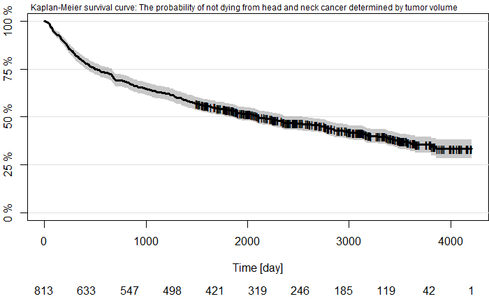

```r
par(mar = c(0.5, 0.05, 1, 0))

# Censoring data: if the patient is dead = 1 or else 0
PET <- PET %>% mutate(is_dead = ifelse(event == "True", 1, 0))

# Creating Kaplan-Meier survival curve
km <- prodlim(Surv(time_to_morse, is_dead) ~ 1, PET)

plot(km,marktime=TRUE,xlab = "Time [day]")
title(main = "Kaplan-Meier survival curve: The probability of not dying from head and neck cancer determined by tumor volume",cex.main=0.78,font.main=1,outer=FALSE)
```

The independent variable in the model is time, where S(t=0) represents the data of the patient’s first PET-CT scan, undertaken with the general purpose of formulating a radiotherapy treatment plan. This scan is typically conducted a week prior to the commencement of the radiotherapy, which is the primary treatment for all patients, and, if judged to be indicated/tolerable, supplemented by cisplatin. From the survival curve an estimated probability of still being event free as a fraction of time since the first PET-CT scan can be read. After around 2000 days (5.5 years) the probability of surviving is 50%, which means that about half the patients has a survival probability within the first five years.

```r
# Setting the desired time points within the range of the data
time_points <- c(1, 2, 12, 14, 17, 22, 24, 34, 38, 41, 42, 47, 50, 100, 200*(1:30), 365)
time_points <- time_points[time_points <= 4300]

# Using the summary function with specified time points
summary(km, times = time_points)
```

```
   time n.risk n.event n.lost  surv se.surv lower upper
1     1    813       0      0 1.000 0.00000 0.000 1.000
2     2    813       1      0 0.999 0.00123 0.996 1.000
3    12    812       1      0 0.998 0.00174 0.994 1.000
4    14    811       1      0 0.996 0.00213 0.992 1.000
5    17    810       1      0 0.995 0.00245 0.990 1.000
6    22    809       2      0 0.993 0.00300 0.987 0.999
7    24    807       1      0 0.991 0.00324 0.985 0.998
8    34    806       1      0 0.990 0.00346 0.983 0.997
9    38    805       1      0 0.989 0.00367 0.982 0.996
10   41    804       1      0 0.988 0.00387 0.980 0.995
11   42    803       1      0 0.986 0.00405 0.979 0.994
12   47    802       1      0 0.985 0.00423 0.977 0.994
13   50    801       1      0 0.984 0.00440 0.975 0.993
14  100    765       0      0 0.941 0.00827 0.925 0.957
```

[output cut: 22 more lines]

For all the head and neck cancer patients in the study from dataset 1, the estimated survival probability after 365 days (one year) is 79.7% with a 95% confidence interval (95%-CI) from 76.9% to 82.5%. After about five years (1800 days) the survival probability is 53.7% with a 95%-CI of 50%.3 to 57.2%. When the survival probability is approximately 50%, as in 50% of the population is dead, about 2200 days (6 years) have passed. The median time to the event of the population can further be examined:

```r
# Finding the median time to the event
quantile(km)
```

```
Quantiles of the event time distribution based on the Kaplan-Meier method.

Table of quantiles and corresponding confidence limits:
```

| q | quantile | lower | upper |
| --- | --- | --- | --- |
| 0.00 | NA | NA | NA |
| 0.25 | NA | NA | NA |
| 0.50 | 2106 | 1823 | 2547 |
| 0.75 | 497 | 422 | 662 |
| 1.00 | 2 | 2 | 17 |

```
Median time (IQR):2106.00 (497.00;NA)
```

The median time to event for HNC at Rigshospitalet is 2106 days, with a 95% confidence interval ranging from 1823 days to 2547 days. The upper 0.75 quantile (reversed from normality (real lower quantile)) is at 497 days, while the lower quantile of 0.25 (0.75 quantile) cannot be estimated. This limitation may arise because, at this point, the observation time is possibly too close to the 100% quantile to accurately estimate the risk for this size.

The metabolic tumor volume (mtv) found by deep learning (dl) is divided into four groups; A group at lower risk (small tumors), a group where patients could benefit from intensified treatment (medium tumors), a group where patients could benefit from even more intensified treatment (large tumors) and a group where patients maybe should not be treated (extra large tumors). The tumor volume radius is approximated, assuming that tumors are roughly represented by a spherical shape.

```r
PET$mtv_dl_r <- (3*PET$mtv_dl /(4*pi))^(1/3)
```

The groups are now divided into four equal portions,

```r
# Get the range of 95% of the data.
lq <- quantile(PET$mtv_dl_r,0.025) # lower quantile 0.025
hq <- quantile(PET$mtv_dl_r,0.975) # higher quantile 0.975
w <- (hq-lq)/4 #width of each cut
b1 <- lq+w # first break
b2 <- lq+2*w# second break
b3 <- lq+3*w# third break
```

where b1, b2, and b3 represent the breaks in the data. Additionally, the data is divided into the four groups mentioned previously, and the size of each is displayed below.

```r
PET$group_radius <- cut(PET$mtv_dl_r, breaks=c(-Inf,b1,b2,b3,Inf), labels=c('small','medium','large','x-large'))
table(PET$group_radius)
```

```
  small  medium   large x-large
    246     312     183      72
```

These four groups are applied to the Kaplan-Meier esimator and the Cox proportional hazard (ph) model below. Subsequently, the KM estimator is used for a log-rank test, with the null hypothesis positing that the survival functions are the same, S1(t) = S2(t).

```r
par(mar = c(0.5, 2.5, 1, 0))

# Fitting the survival model
km_groups <- prodlim(Surv(time_to_morse/365, is_dead) ~ group_radius, PET, conf.int = 0.95)

# Plotting the Kaplan-Meier curves
plot(km_groups, xlab = "Time [year]", legend = FALSE, atRisk.cex = 0.8, atrisk.title = "Patients still alive at time, t", col = 1:4, marktime = TRUE)
legend("topright", legend = c("Small", "Medium", "Large", "x-large"), cex = 0.9, inset = 0, col = 1:4, lty = 1)
```

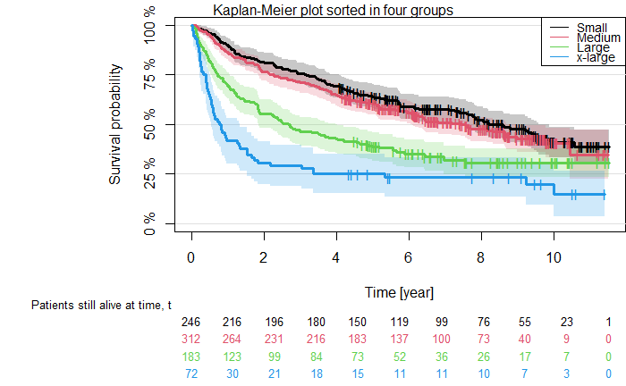

```r
title(main = "Kaplan-Meier plot sorted in four groups", cex.main = 1, font.main = 1, outer = FALSE)
```

The curves depict the 95%-confidence intervals, represented by the colored areas around them. Each pin on the curve signifies censored patients. Below the plot, the patients (those still alive) at risk, at a given time, are displayed. The risk is given by the individuals being at risk of dying just before time, t, which is the observed failure time. The probability of not experiencing the event is estimated to be similar for the small and medium tumor volume groups, both showing higher survival probabilities than the large and x-large groups. Utilizing the Kaplan-Meier survival curves reveals a correlation between tumor volume and survival probability. Notably, smaller tumor volumes are associated with higher survival probabilities. Expect from the small and medium groups, since they appear almost identical, a significant difference is observed between the metabolic tumor volume groups. This is until approximately nine years after the scan, where the confidence intervals start to overlap. This may be attributed to the progression of cancer for each patient over the extended timeframe. This suggests that at a certain point, tumors in the smaller group may have grown large enough to impact patient survival the same way as the larger groups, whereas individual episodes account for patients already presenting with large or x-large tumors, thus they are still alive.

The survival probability of the event is now examined

```r
summary(km_groups)
```

```
   group_radius     time n.risk n.event n.lost  surv se.surv lower upper
1         small  0.00548    246       0      0 1.000 0.00000 0.000 1.000
2         small  1.62671    206       0      0 0.837 0.02353 0.791 0.884
3         small  4.93562    146       0      0 0.644 0.03066 0.584 0.704
4         small  7.84041     83       0      0 0.533 0.03382 0.467 0.600
5         small 11.53151      1       0      1 0.388 0.04236 0.305 0.471
6        medium  0.00548    312       0      0 1.000 0.00000 0.000 1.000
7        medium  1.62671    252       0      0 0.808 0.02231 0.764 0.851
8        medium  4.93562    170       0      0 0.605 0.02775 0.550 0.659
9        medium  7.84041     76       0      0 0.474 0.03094 0.414 0.535
10       medium 11.53151      0       0      0    NA      NA    NA    NA
11        large  0.00548    183       1      0 0.995 0.00545 0.984 1.000
12        large  1.62671    112       0      0 0.612 0.03602 0.541 0.683
13        large  4.93562     66       0      0 0.393 0.03616 0.322 0.464
14        large  7.84041     26       0      0 0.307 0.03674 0.235 0.379
15        large 11.53151      0       0      0    NA      NA    NA    NA
16      x-large  0.00548     72       0      0 1.000 0.00000 0.000 1.000
17      x-large  1.62671     25       0      0 0.347 0.05611 0.237 0.457
18      x-large  4.93562     14       0      0 0.250 0.05103 0.150 0.350
19      x-large  7.84041     10       0      0 0.232 0.05041 0.133 0.331
20      x-large 11.53151      0       0      0    NA      NA    NA    NA
```

The output displays the survival probability at five different times, t, for each group. For the head and neck cancer group, with small tumor volumes, the estimated survival probability of surviving after about five years are 64.4% (95%-CI: 58.4% to 70.4%), for the medium group it is 60.5% (95%-CI: 55.0% to 65.9%)l, for the large group it is 39.3% (95%-CI: 32.2% to 46.4%) and within the x-large group the survival probability is 25% (95%-CI: 15% to 35%). This analysis emphasizes the observation from the Kaplan-Meier survival curves above.

```r
quantile(km_groups)
```

```
Quantiles of the event time distribution based on the Kaplan-Meier method.

Table of quantiles and corresponding confidence limits:
```

| group_radius | q | quantile | lower | upper |
| --- | --- | --- | --- | --- |
| small | 0.00 | NA | NA | NA |
| small | 0.25 | NA | NA | NA |
| small | 0.50 | 8.210958904 | 7.397260274 | 9.59452055 |
| small | 0.75 | 3.161643836 | 2.290410959 | 3.91780822 |
| small | 1.00 | 0.046575342 | 0.046575342 | 0.15616438 |
| medium | 0.00 | NA | NA | NA |
| medium | 0.25 | NA | 10.446575342 | NA |
| medium | 0.50 | 7.432876712 | 6.068493151 | 8.99726027 |
| medium | 0.75 | 2.271232877 | 1.854794521 | 3.29863014 |
| medium | 1.00 | 0.104109589 | 0.104109589 | 0.18630137 |

[output cut: 10 more lines]

```
group_radius = 1 :Median time (IQR):8.21 (3.16;NA)
group_radius = 2 :Median time (IQR):7.43 (2.27;NA)
group_radius = 3 :Median time (IQR):2.68 (0.73;NA)
group_radius = 4 :Median time (IQR):0.83 (0.40;5.33)
```

The median time to event for the small metabolic tumor volume group indicates a survival probability of 50% at 8.2 years [95%-CI from 7.4 years to 9.6 years]. The 0.75 quantile is 3.2 years, but the 0.25 quantile cannot be estimated. This limitation may arise for the same reason as mentioned above. For the medium group, the median time to event is 7.4 years (95%-CI 6.1 years - 9.0 years). The median time to event for the large group is 2.7 years (95%-CI 1.8 years to 4.0 years), and the x-large group is 0.8 with a 95%-CI within the range of 0.6 to 1.4 years.

Through the log-rank test the null hypothesis is tested between each of the groups, where the null hypothesis is the same as above - there is no difference in the survival functions.

```r
# The four groups are defined
groups <- c("small", "medium", "large", "x-large")

# Log-rank tests performed between the four different groups
test_results <- lapply(1:(length(groups)-1), function(i) {
  for (j in (i+1):length(groups)) {
    # Perform log-rank test for each pair of groups
    result <- survdiff(Surv(time_to_morse, is_dead) ~ group_radius, subset = group_radius %in% c(groups[i], groups[j]), data = PET)
    print(result)

    # Calculate the adjusted p-value using Bonferroni correction in order to make the adjustments for multiple testing
    adjusted_p_value <- pchisq(result$chisq, df = 1, lower.tail = FALSE) * (length(groups)*(length(groups)-1))/2

    # Print the adjusted p-value
    cat("Adjusted p-value:", adjusted_p_value, "\n\n")
  }
})
```

```
Call:
survdiff(formula = Surv(time_to_morse, is_dead) ~ group_radius,
    data = PET, subset = group_radius %in% c(groups[i], groups[j]))

                      N Observed Expected (O-E)^2/E (O-E)^2/V
group_radius=small  246      124      133     0.556      1.05
group_radius=medium 312      160      151     0.487      1.05

 Chisq= 1.1  on 1 degrees of freedom, p= 0.3
Adjusted p-value: 1.831852

Call:
survdiff(formula = Surv(time_to_morse, is_dead) ~ group_radius,
    data = PET, subset = group_radius %in% c(groups[i], groups[j]))

                     N Observed Expected (O-E)^2/E (O-E)^2/V
group_radius=small 246      124      162      8.93      26.5
group_radius=large 183      122       84     17.24      26.5

 Chisq= 26.5  on 1 degrees of freedom, p= 3e-07
Adjusted p-value: 1.602554e-06

Call:
survdiff(formula = Surv(time_to_morse, is_dead) ~ group_radius,
    data = PET, subset = group_radius %in% c(groups[i], groups[j]))

                       N Observed Expected (O-E)^2/E (O-E)^2/V
group_radius=small   246      124    157.8      7.26      57.6
group_radius=x-large  72       57     23.2     49.48      57.6

 Chisq= 57.6  on 1 degrees of freedom, p= 3e-14
Adjusted p-value: 1.972561e-13

Call:
survdiff(formula = Surv(time_to_morse, is_dead) ~ group_radius,
    data = PET, subset = group_radius %in% c(groups[i], groups[j]))

                      N Observed Expected (O-E)^2/E (O-E)^2/V
group_radius=medium 312      160    195.5      6.43      21.1
group_radius=large  183      122     86.5     14.53      21.1
```

[output cut: 10 more lines]

```
group_radius=x-large  72       57     24.1      44.8      51.1

 Chisq= 51.1  on 1 degrees of freedom, p= 9e-13
Adjusted p-value: 5.393054e-12

Call:
survdiff(formula = Surv(time_to_morse, is_dead) ~ group_radius,
    data = PET, subset = group_radius %in% c(groups[i], groups[j]))

                       N Observed Expected (O-E)^2/E (O-E)^2/V
group_radius=large   183      122    139.8      2.27      10.4
group_radius=x-large  72       57     39.2      8.09      10.4

 Chisq= 10.4  on 1 degrees of freedom, p= 0.001
Adjusted p-value: 0.007374478
```

```r
# Critical value calculated for each log-rank test by defining degrees of freedom and choosing a two-sided test and alpha level
df <- 1
alpha <- 0.05
critical_value <- qchisq(1 - alpha/2, df)
cat("Critical Value:", critical_value, "\n")
```

```
Critical Value: 5.023886
```

The log-rank test provides information on five different categories: N (total number of the group), Observed (number of observed cases where a patient died), Expected (number of expected cases, representing the number of patients who were anticipated to die), (O-E)^2/E (the squared difference between observed and expected cases divided by the number of expected cases), and (O-E)^2/V (a measure of variance). The estimated variance is utilized to assess differences between the two groups in case they have the same hazard function. The hazard function conveys information about the instantaneous risk of dying at a given time, t, among patients still alive (Professor Marin, 2020).

A simple Cox proportional hazard model is fitted, in order to further examine the survival probability between the four groups of tumor volumes.

```r
# Specifying the desired order of reference groups
reference_order <- c("small", "medium", "large")

# Creating an empty list to store the Cox model summaries
cox_summaries <- list()

# Iterate through each reference group
for (ref_group in reference_order) {
  # Set the reference group
  PET$group_radius <- relevel(PET$group_radius, ref = ref_group)


par()
  # Fit the Cox model
  cox.simple_model <- coxph(Surv(time_to_morse/365, is_dead) ~ group_radius, data = PET)

  # Store the model summary in the list
  cox_summaries[[paste("Reference Group for tumor volume grous:", ref_group)]] <- summary(cox.simple_model)
}

print(cox_summaries)
```

```
$`Reference Group for tumor volume grous: small`
Call:
coxph(formula = Surv(time_to_morse/365, is_dead) ~ group_radius,
    data = PET)

  n= 813, number of events= 463

                      coef exp(coef) se(coef)     z Pr(>|z|)
group_radiusmedium  0.1029    1.1084   0.1199 0.859     0.39
group_radiuslarge   0.6449    1.9059   0.1280 5.040 4.65e-07 ***
group_radiusx-large 1.1794    3.2523   0.1608 7.334 2.23e-13 ***
---
Signif. codes:  0 ‘***’ 0.001 ‘**’ 0.01 ‘*’ 0.05 ‘.’ 0.1 ‘ ’ 1

                    exp(coef) exp(-coef) lower .95 upper .95
group_radiusmedium      1.108     0.9022    0.8764     1.402
group_radiuslarge       1.906     0.5247    1.4831     2.449
group_radiusx-large     3.252     0.3075    2.3731     4.457

Concordance= 0.615  (se = 0.013 )
Likelihood ratio test= 64.77  on 3 df,   p=6e-14
Wald test            = 73.88  on 3 df,   p=6e-16
Score (logrank) test = 79.43  on 3 df,   p=<2e-16


$`Reference Group for tumor volume grous: medium`
Call:
coxph(formula = Surv(time_to_morse/365, is_dead) ~ group_radius,
    data = PET)

  n= 813, number of events= 463

                       coef exp(coef) se(coef)      z Pr(>|z|)
group_radiussmall   -0.1029    0.9022   0.1199 -0.859     0.39
group_radiuslarge    0.5420    1.7195   0.1204  4.502 6.72e-06 ***
group_radiusx-large  1.0764    2.9342   0.1550  6.944 3.81e-12 ***
---
Signif. codes:  0 ‘***’ 0.001 ‘**’ 0.01 ‘*’ 0.05 ‘.’ 0.1 ‘ ’ 1

                    exp(coef) exp(-coef) lower .95 upper .95
```

[output cut: 18 more lines]

```
group_radiusmedium  -0.5420    0.5816   0.1204 -4.502 6.72e-06 ***
group_radiussmall   -0.6449    0.5247   0.1280 -5.040 4.65e-07 ***
group_radiusx-large  0.5344    1.7065   0.1608  3.324 0.000888 ***
---
Signif. codes:  0 ‘***’ 0.001 ‘**’ 0.01 ‘*’ 0.05 ‘.’ 0.1 ‘ ’ 1

                    exp(coef) exp(-coef) lower .95 upper .95
group_radiusmedium     0.5816      1.719    0.4593    0.7363
group_radiussmall      0.5247      1.906    0.4083    0.6743
group_radiusx-large    1.7065      0.586    1.2452    2.3386

Concordance= 0.615  (se = 0.013 )
Likelihood ratio test= 64.77  on 3 df,   p=6e-14
Wald test            = 73.88  on 3 df,   p=6e-16
Score (logrank) test = 79.43  on 3 df,   p=<2e-16
```

Below, the Cox ph model is utilized to predict the survival probability of head and neck cancer patients, and the curves display the probability for each tumor volume.

```r
pred.cox = survfit(cox.simple_model, newdata = data.frame(group_radius=c("small","medium","large","x-large")))
plot(pred.cox, col=1:4, xlab="Time [year]", ylab="Survival probability")
legend("topright", inset=.0,cex=0.9, col=1:4, lty=1, c("Small","Medium", "Large", "X-large"))
```

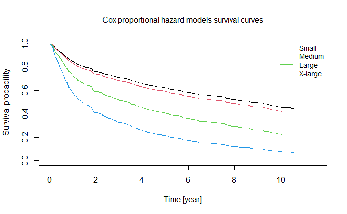

```r
title(main = "Cox proportional hazard models survival curves",cex.main=1,font.main=1,outer=FALSE)
```

As advocated above, small and medium sized tumors are close to having the same survival probability, but there is a clear difference between the other groups. The Kaplan-Meier and Cox regressions model is now plotted on the same canvas.

```r
par(mar = c(0.5, 2.5, 1, 0))
# Get predicted survival probabilities from the Cox model and plot with the Kaplan-Meier survival curves
plot(km_groups, col=1:4, xlab="Time [year]", ylab="Survival probability", legend=FALSE)
legend("topright", inset=.0,cex=0.9, col=1:4, lty=1, c("Small","Medium", "Large", "X-large"))
```

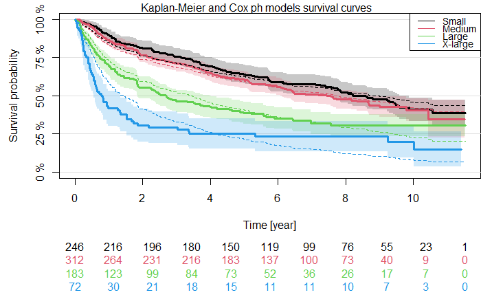

```r
title(main = "Kaplan-Meier and Cox ph models survival curves",cex.main=1,font.main=1,outer=FALSE)
lines(pred.cox, col=1:4, lty=2)
```

The Kaplan-Meier (solid lines with confidence interval) and Cox (dotted lines) survival curves according to the tumor groups exhibit a striking resemblance. The Cox curves are derived with the assumption that hazards are proportionate, implying they should not intersect.The proportional hazard assumption is, that the hazard ratio does not depend on time, hence the hazard is proportional to each other over time. However, even though the curves do not intersect, they do not follow a proportional regression either, which especially counts for the x-large group. The assumptions is therefor further investigated, in order to disclose, weather or not the assumptions are violated, although the differences between the curves for the x-large group suggest that the assumptions are violated.

An additive Cox model with sex and age as confounders is now made, since these are decided to be the covariates most relevant to interpret. Coufounders are variables related to the independent variable (tumor volume) and the dependent variable (the event(death). The survival probability is investigated with the addition of the confounders and compared to the Kaplan-Meier model, as done above.

```r
# Createing an empty list to store the Cox model summaries
cox_summaries <- list()

# Iterate through each reference group
for (ref_group in reference_order) {
  # Set the reference group for 'group_radius'
  PET$group_radius <- relevel(PET$group_radius, ref = ref_group)

  # Fit the additive Cox model
  cox.additive_model <- coxph(Surv(time_to_morse/365, is_dead) ~ sex + group_radius + age_at_scan, data = PET)

  # Store the model summary in the list
  cox_summaries[[paste("Reference sroup for tumor volume grous:", ref_group)]] <- summary(cox.additive_model)
}

print(cox_summaries)
```

```
$`Reference sroup for tumor volume grous: small`
Call:
coxph(formula = Surv(time_to_morse/365, is_dead) ~ sex + group_radius +
    age_at_scan, data = PET)

  n= 813, number of events= 463

                        coef exp(coef) se(coef)     z Pr(>|z|)
sexm                0.003795  1.003802 0.104852 0.036    0.971
group_radiuslarge   0.737756  2.091238 0.128769 5.729 1.01e-08 ***
group_radiusmedium  0.182851  1.200635 0.120509 1.517    0.129
group_radiusx-large 1.188573  3.282394 0.161300 7.369 1.72e-13 ***
age_at_scan         0.037122  1.037819 0.004668 7.952 1.83e-15 ***
---
Signif. codes:  0 ‘***’ 0.001 ‘**’ 0.01 ‘*’ 0.05 ‘.’ 0.1 ‘ ’ 1

                    exp(coef) exp(-coef) lower .95 upper .95
sexm                    1.004     0.9962    0.8173     1.233
group_radiuslarge       2.091     0.4782    1.6248     2.692
group_radiusmedium      1.201     0.8329    0.9481     1.521
group_radiusx-large     3.282     0.3047    2.3927     4.503
age_at_scan             1.038     0.9636    1.0284     1.047

Concordance= 0.671  (se = 0.013 )
Likelihood ratio test= 131.1  on 5 df,   p=<2e-16
Wald test            = 143.5  on 5 df,   p=<2e-16
Score (logrank) test = 146.9  on 5 df,   p=<2e-16


$`Reference sroup for tumor volume grous: medium`
Call:
coxph(formula = Surv(time_to_morse/365, is_dead) ~ sex + group_radius +
    age_at_scan, data = PET)

  n= 813, number of events= 463

                         coef exp(coef)  se(coef)      z Pr(>|z|)
sexm                 0.003795  1.003802  0.104852  0.036    0.971
group_radiussmall   -0.182851  0.832892  0.120509 -1.517    0.129
group_radiuslarge    0.554906  1.741776  0.120886  4.590 4.43e-06 ***
```

[output cut: 30 more lines]

```
age_at_scan          0.037122  1.037819  0.004668  7.952 1.83e-15 ***
---
Signif. codes:  0 ‘***’ 0.001 ‘**’ 0.01 ‘*’ 0.05 ‘.’ 0.1 ‘ ’ 1

                    exp(coef) exp(-coef) lower .95 upper .95
sexm                   1.0038     0.9962    0.8173    1.2328
group_radiusmedium     0.5741     1.7418    0.4530    0.7276
group_radiussmall      0.4782     2.0912    0.3715    0.6155
group_radiusx-large    1.5696     0.6371    1.1410    2.1591
age_at_scan            1.0378     0.9636    1.0284    1.0474

Concordance= 0.671  (se = 0.013 )
Likelihood ratio test= 131.1  on 5 df,   p=<2e-16
Wald test            = 143.5  on 5 df,   p=<2e-16
Score (logrank) test = 146.9  on 5 df,   p=<2e-16
```

```r
par(mar = c(0.5, 2.5, 1, 0))
# Get predicted survival probabilities from the Cox model with covariaties and plot with the Kaplan-Meier survival curves
plot(km_groups, col=1:4, xlab="Time (days)", ylab="Survival probability", legend = FALSE)
legend("topright", inset=.0, col=1:4, lty=1, cex=0.9, c("Small","Medium", "Large", "X-large"))
```

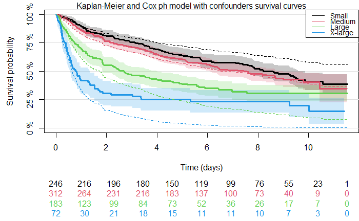

```r
pred.cox_additive <- survfit(cox.additive_model, newdata = data.frame(sex=c("m","f","m","f"),age_at_scan=c(55,65,75,85), group_radius=c("small","medium","large","x-large")))
title(main="Kaplan-Meier and Cox ph model with confounders survival curves",cex.main=1,font.main=1,outer=FALSE)

lines(pred.cox_additive, col=1:4, lty=2)
```

The Kaplan-Meier and additive Cox model survival curves have been plotted together to compare their predictions, and they appear quite different compared to the previous plot without the confounders added. The curves for the medium group follow the same predictions for the two models, but the rest of the categories have different regressions. Especially pronounced is the difference for the large and x-large group, where the adjusted Cox model decreases faster than the Kaplan-Meier model and simple Cox model. There is also a difference between the curves for the small tumor volume group, where the Cox model decreases slower than the Kaplan-Meier model. This gives rise to testing if the assumptions are violated.

By examining the covariates and the additive Cox model, it prompts an exploration of the assumptions of the Cox proportional hazard model as mentioned before:

1. The censoring is non-informative, meaning it is independent. If someone was censored, it does not imply that they were more or less likely to die. It is assumed to be random and not informative.
2. Hazards are proportional, indicating that the hazard ratio is constant over time.
3. The logarithm of the hazard function, log(Haz), is linear in relation to each covariate.

The first assumption cannot be tested for violation, so there is nothing to be done about it if the assumptions does not hold. However, proportionality and linearity can be investigated to examine if they are violated. The proportional hazard is checked through a goodness of fit (gof) test, and more specific is it a cumulative martingale residuals test (Professor Marin, 2020).

```r
# Fitting the proportional hazards model
Surv_Object <- with(PET, Surv(time_to_morse, is_dead))
cox.prop <- phreg(Surv_Object ~ sex + group_radius + age_at_scan,data=PET)

# Assess the goodness of fit
goodness_of_fit <- gof(cox.prop)
print(goodness_of_fit)
```

```
Cumulative score process test for Proportionality:
                     Sup|U(t)|  pval
sexm                  4.493788 0.960
group_radiusmedium   16.524047 0.009
group_radiussmall    15.746522 0.004
group_radiusx-large  17.393461 0.000
age_at_scan         239.784942 0.111
```

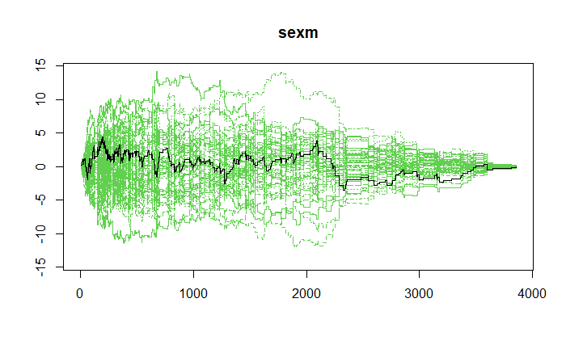

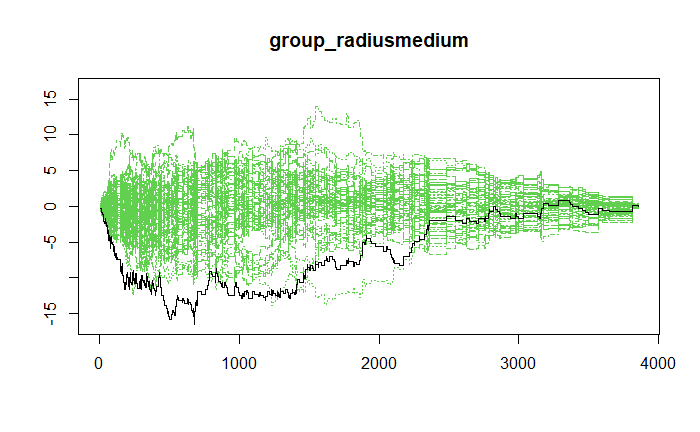

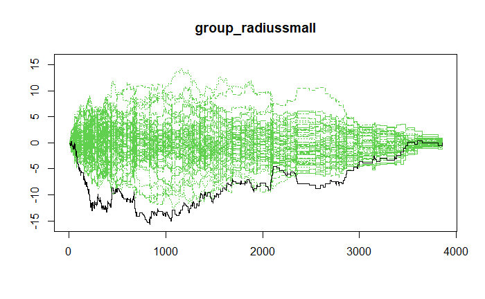

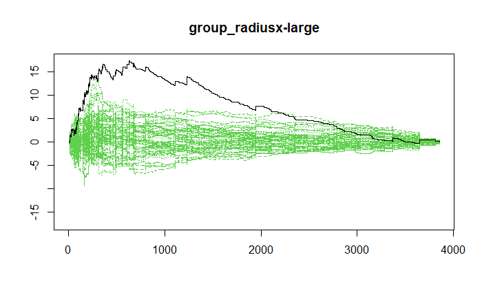

```r
plot(goodness_of_fit)
```

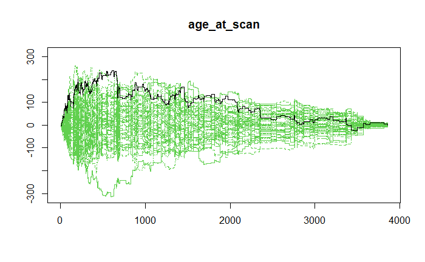

```r
NA
```

The third assumption is now assessed by testing for non-linearity, achieved by plotting the martingale residuals against continuous covariates. In this analysis, the metabolic tumor volume is considered along with its logarithm and squared variations of said variable.

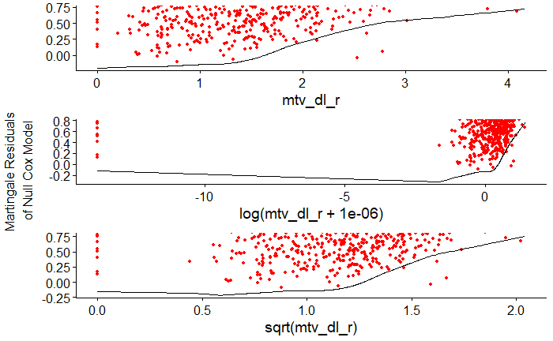

```r
cox_linearity <- coxph(Surv(time_to_morse, is_dead) ~ mtv_dl_r + log(mtv_dl_r + 0.000001) + sqrt(mtv_dl_r), data = PET)
ggcoxfunctional(cox_linearity, data = PET)
```

It is evident that a significant degree of non-linearity exists, as observed in the different shapes of the curves depicting continuous covariates against the martingale residuals of the null Cox proportional hazards model. Furthermore, the data is clustered and does not exhibit a uniform spread across the entire canvas, providing additional evidence of a violation of the assumption. These graphs, coupled with the assessments discussed earlier, unequivocally demonstrate that the Cox proportional hazard model violates its underlying assumptions. This issue might have been mitigated by selecting a defined, shorter time period for the event to occur or having three metabolic tumor volumes instead of four.

To assess the performance of the prediction model, we examine the area under the receiver operating characteristic (ROC) curve (AU(ROC)C), which “represents the degree or measure of separability” (Narkhede, 2018). The AUROCC provides insights into the probability that a patient who has experienced an event has a higher risk than one who has not experienced an event. In the presence of censoring in the model, this assessment is estimated using inverse probability of censoring weights — a method employed to adjust for potential bias in the model due to informative censoring. Essentially, individuals less likely to be censored are assigned higher weights, so each observation is weighted based on the probability of being censored (Gerds & Kattan, 2021, p.131-132).

```r
fit_auc <- coxph(Surv(time_to_morse, is_dead) ~ sex + group_radius + age_at_scan, data=PET, x=1)
auc <- Score(list("Cox regression"=fit_auc), data = PET, formula = Surv(time_to_morse, is_dead) ~ 1, times=seq(365.25,365.25*10,365.25), metrics="auc")
# (Gerds & Kattan, 2021, p.132)
auc$AUC$score[times==365.25*10]
```

| model | times | AUC | se | lower | upper |
| --- | --- | --- | --- | --- | --- |
| Cox regression | 3652.5 | 0.6639937 | 0.03991297 | 0.5857657 | 0.7422217 |

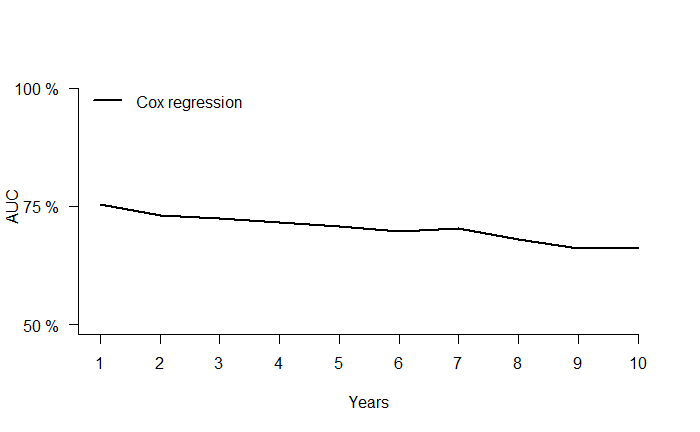

```r
plotAUC(auc,axis1.at=seq(0,365.25*10,365.25),axis1.lab=0:10,xlab="Years")
```

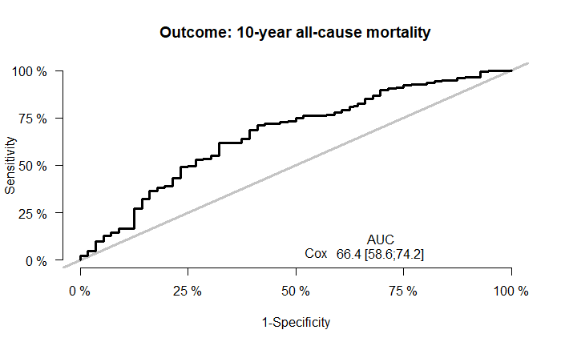

```r
fit_roc <- coxph(Surv(time_to_morse, is_dead) ~ sex + group_radius + age_at_scan, data=PET, x=1L)
roc <- Score(list("Cox"=fit_roc),data=PET, formula = Surv(time_to_morse, is_dead) ~ 1, times=365.25*10, metrics=c("auc"),plots="ROC")
plotROC(roc, plot.main="Outcome: 10-year all-cause mortality")
```

```r
# (Gerds & Kattan, 2021, p.1331)
```

The AUC is 66.4% [95%-CI 58.6% to 74.2%], indicating the probability that the Cox regression model assigns a higher predicted 10-year mortality risk to a randomly chosen patient who dies within ten years compared to a randomly selected patient who survives within the same timeframe. Higher AUC values suggest a better model, as they represent the model’s ability to distinguish between patients who die or survive by the end of the time horizon. An AUC of 50% would mean the model cannot discriminate, while an AUC close to zero characterizes a poor model, although it provides more information than a 50% AUC (Gerds & Kattan, 2021, p. 117). Correspondingly, the ROC curve is employed to predict the 10-year risk of all-cause mortality for dataset 1. The Cox regression model utilizes the patient’s sex, age at the time of the scan, and metabolic tumor volume to make these predictions, assisted by the inverse probability of censoring weights. The specificity (true negative rate (TNR)) and sensitivity (true positive rate (TPR)) of the model are inversely proportional, why the x-axis displays 1-specificity (false positive rate (FPR)) to make them directly proportional. This puts TPR against FPR for the threshold. The TPR is the probability that the model predicts a positive outcome, which is indeed a positive outcome, and FPR is the probability to predict a positive outcome, which is indeed a negative outcome (Florkowski, 2008). With an AUC of 66.4%, the model performs moderately well in obtaining true positives, meaning that the Cox model, 66.4% of time, correctly will identify true positives. From the ROC curve, this is evident: lowering the classification threshold results in more positive outcomes, and increasing the threshold leads to both positive and negative outcomes.

If interested in further analysis, the knowledge gained from the trained model could now be validated on other datasets, such as those filtered out (datasets 2 to 5) earlier in this analysis. This would provide an estimate of how well the model performs on unseen patients by decresing the risk of overfitting, and thereby protecting the analysis. However, this validation is not conducted in this report.

The advantages of using AUROCC as an analytical method to evaluate the performance of a model, lie in the fact that the performance evaluation is not tied to a specific threshold, contributing to the robustness of the assessment. This means, when Cox provides the patient with some kind of risk score for an event occurring, the data is classified and tested through the area under the receiver operating characteristic curve, with an assessment highly applicable. Furthermore, neither sensitivity nor specificity is affected by the prevalence of the disease; hence, the AUC and ROC are independent. The ROC curve can also be easily compared to a correlated ROC curve, where the covariance of several diagnostic tasks on the same subject can be evaluated. These advantages make the AUROCC a valuable tool for reviewing a model based on how well it can classify correctly in a clinical setting (Hajian-Tilaki , 2013).

The analysis above highlights certain limitations of the Cox proportional hazard model. One notable limitation, which, lately, is widely critiqued is the hazard ratio as an effect measure and not an actual critique of the Cox ph model. This concerns the interpretation of the hazard ratio for two main reasons: it changes over time despite the assumption that it does not, and it has a built-in selection bias (Hernán, 2010). The former addresses the concern that, the conclusions can be misleading depending on the follow-up duration for the averaged HR. If the choice of duration is arbitrary, different durations could result in different hazard ratios. Regarding the latter critiqued point, the bias arises because the calculation of the hazard ratio is restricted to patients who have not developed an outcome by the end of the defined time period. When having the built-in selection bias, the outcome of the study might appear better or worse than it actually is, thus it might undermine the validity of the HR. All of this sums up the fact that the Cox hazard ratio might not be casually interpretable as a hazard ratio unless it meets unrealistic assumptions or where it has no causal effect (Martinussen, 2022). Regarding this report, some of the pitfalls of the Cox ph model lie on the fact, that the follow-up duration is long, which will never provide a Hazard ratio constant over time, thus the assumption does not hold. Besides this downfall, the model does not take competing risks into consideration, which could be relevant to interpret.

### Literature

Andersen, P. K., et al. “Analysis of time-to-event for observational studies: Guidance to the use of intensity models”. Statistics in Medicine, Sep. 2020. DOI: 10.1002/stm.8757

Florkowski, C. M. “Sensitivity, specificity, receiver-operating characteristic (ROC) curves and likelihood ratios: communicating the performance of diagnostic tests”. Clin Biochem Rev. 2008 Aug;29 Suppl 1(Suppl 1):S83-7. PMID: 18852864; PMCID: PMC2556590.

Hajian-Tilaki K. “Receiver Operating Characteristic (ROC) Curve Analysis for Medical Diagnostic Test Evaluation”. Caspian J Intern Med. 2013 Spring;4(2):627-35. PMID: 24009950; PMCID: PMC3755824.

Hernán, M. A. “The Hazards of Hazard Ratios”. Epidemiology. 2010. DOI: 10.1097/EDE.0b013e3181c1ea43

Martinussen, T. “Causality and the Cox Regression Model”. Annual Review of Statistics and Its Application. Mar. 2022.DOI: 10.1146/annurev-statistics-040320-114441

Narkhede, Sarang. “Understanding AUC - ROC Curve”.Towards Data Science 20218, https://towardsdatascience.com/understanding-auc-roc-curve-68b2303cc9c5

Professor Marin. ” Introduction to Programming with R Statistical Software | R Course for Beginners” [Video 1- 11 from channel]. YouTube. Apr. 2020. https://www.youtube.com/playlist?list=PLqzoL9-eJTNDdnKvep_YHIwk2AMqHhuJ0

T. A. Gerds, M. W. Kattan. Medical risk prediction models: with ties to machine learning. Taylor & Francis Ltd. 2021. ISBN: 9781138384477

T. Shceike, F. Eriksson. “1. Introduction, 2. Cox I: Coxregression & Cox II: The Proportional Hazards Assumption, time-dependent covariates/covariate effects”. E23:Survival and Event History Analysis, January 19th 2024, Section of Biostatistics, University of Copenhagen: Department of Public Health, https://absalon.ku.dk/courses/70944/